# DAR F21 Project Status 4 Observing Trends through Users’ Average Transactions

IDEA-Blockchain (DeFi)

Duke Kwon

10/14/21

## Personal Contribution

- All code and explanation in this notebook was done by me.

## Discussion of Primary Findings

- What did you want to know?
  - After using heatmaps and density estimates of the features to compare differences by cluster, a lot of information was not utilized to its fullest extent. Mainly, types, amounts, and frequencies of transaction for each of the users by clusters through time might provide a better understanding of the groupings.
- How did you go about finding it?
  - The visualizations used were stacked barplots through time - averaged weekly transactions by transaction type and for the largest 3 clusters.
- What did you find?
  - By comparing side by side, differences in overall behavior/style of transactions was found, though the differences still need to be better interpreted.

## Preliminary Data Loading

```r
library(ggplot2)
library(dplyr)
library(tidyverse)
library(lubridate)
library(data.table)
library(ggridges)
```

We start with loading in the data generated from the previous assignments - cluster labels and the original transaction data.

```r
#write_csv(df.4, file='unique_users_avg_wClusters_assign4.csv') ## users_clustered
df.4 <- read_csv("unique_users_avg_wClusters_assign4.csv")
#df.4 <- df.4[, -which(names(df.4) %in% c("X"))] ## get rid of extra row indices column
df.users <-read.csv("df_users.csv") ## read users parsed csv
df.users <- df.users[, -which(names(df.users) %in% c("X"))]
df_tr<-read_csv('transactions_2.csv') ## original transactions data (not unique users from Jan to Aug. 2021)
N <- max(df.4$hdb_clusters)
dict <- table(df.4$hdb_clusters) #
df.dict <- as.data.frame(dict)   # Unused except to sort by top clusters in the next code block
```

Since we plan on doing analysis through time, we use the lubridate package to make the timestamps interpretable.

```r
df_tr$ymd <- as_datetime(df_tr$timestamp) # fix times for the transactions

setDT(df_tr)[, ymd_new := format(as.Date(ymd), '%Y-%m-%V') ] ## '%Y-%m' for just month-year
df_tr$ymd_new_d <- as.Date(df_tr$ymd_new, "%Y%m%d")
```

## Plotting Weekly Transactions of All Users

We start by taking a look at the entire user transactions data, to have a baseline result to compare the plots by cluster to.

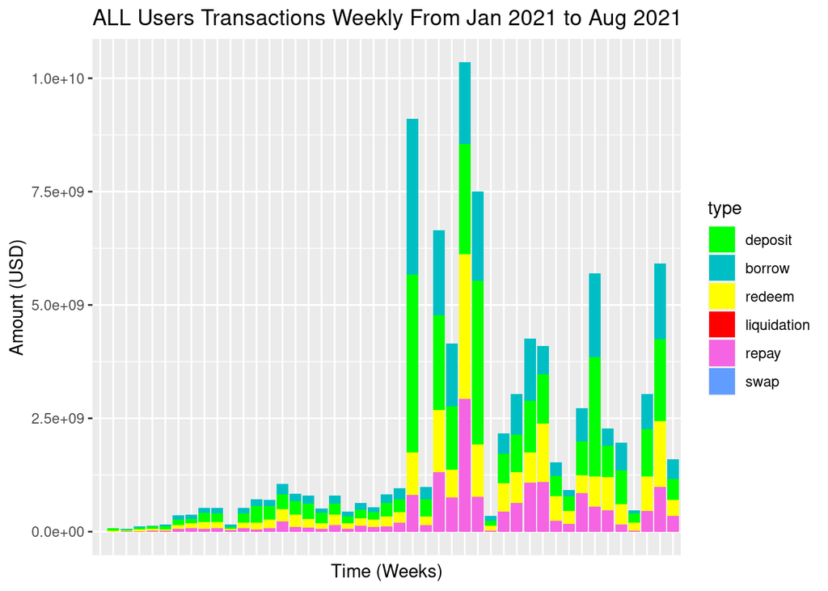

```r
# generate N list of custom colors
gg_color_hue <- function(n) {
  hues = seq(15, 375, length = n + 1)
  hcl(h = hues, l = 65, c = 100)[1:n]
}

# 6-list of ggplot colors explicitly specified
pgg <- gg_color_hue(6)

# Start plotting weekly by time. Start with all Users first
df_tr %>%
  count(ymd_new, type, wt = amount, name = "amount") %>%
ggplot() +
  geom_bar(aes(x=ymd_new,y= amount, fill = type),
           stat='identity') + ggtitle("ALL Users Transactions Weekly From Jan 2021 to Aug 2021") + labs(y = "Amount (USD)", x= "Time (Weeks)")+
          theme(
           axis.text.x=element_blank(),
           axis.ticks.x=element_blank())+
          scale_fill_manual("type", values = c("deposit"="green","borrow" = pgg[4], "redeem" = "yellow", "liquidation" = "red","repay"=pgg[6],"swap"=pgg[5]))
```

```r
# The only important command within geom_bar() is scale_fill_manual() - it's setting custom colors for deposit (green) and liquidations (red). The rest
# are filled by the list generated by gg_color_hue, which contains a palette of colors
```

## Plotting Weekly Transactions of Users by Cluster

Since it’s still relatively hard to compare the results via a stacked plot like this one, we then plot the averaged weekly amounts of a specific transaction type next.

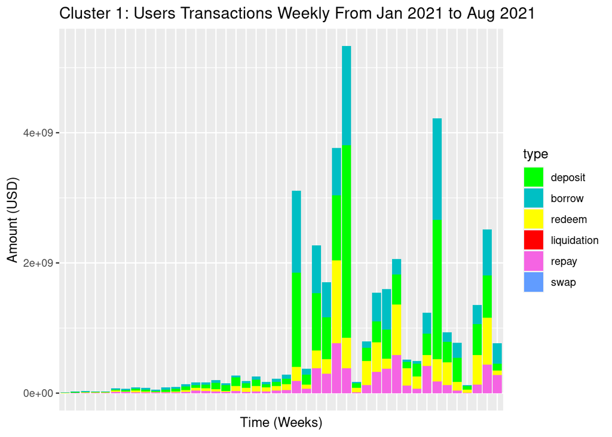

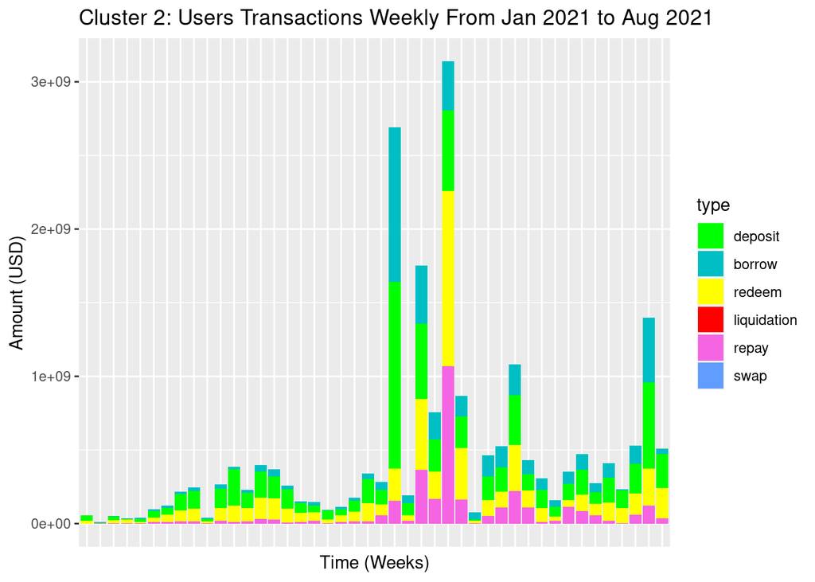

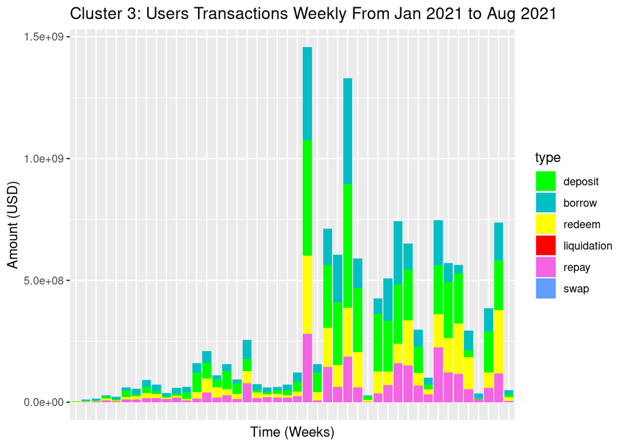

```r
clplt = list()
for (m in 1:3) {
  cluster.plt_loop_temp <- ggplot(count(cluster_transactions[[m]] ,ymd_new, type, wt = amount, name = "amount")) +
  geom_bar(aes(x=ymd_new,y= amount, fill = type),
           stat='identity') + ggtitle(paste0("Cluster ",m,": Users Transactions Weekly From Jan 2021 to Aug 2021")) + labs(y = "Amount (USD)", x= "Time (Weeks)")+
          theme(
           axis.text.x=element_blank(),
           axis.ticks.x=element_blank())+
          scale_fill_manual("type", values = c("deposit"="green","borrow" = pgg[4], "redeem" = "yellow", "liquidation" = "red","repay"=pgg[6],"swap"=pgg[5]))

  clplt[[m]] <- cluster.plt_loop_temp
  print(clplt[[m]])
}
```

```r
deposit_only <- list()
liquidation_only <- list()
repay_only_list <- list()
redeem_only_list <- list()
borrow_o <- list()
for (i in 1:3) {
  dep_only_rows <- cluster_transactions[[i]][cluster_transactions[[i]]$type == "deposit"]
  liq_only_rows  <- cluster_transactions[[i]][cluster_transactions[[i]]$type == "liquidation"]
  rep_r <-  cluster_transactions[[i]][cluster_transactions[[i]]$type == "repay"]
  red_r <-  cluster_transactions[[i]][cluster_transactions[[i]]$type == "redeem"]
  bor_r <-  cluster_transactions[[i]][cluster_transactions[[i]]$type == "borrow"]
  dep_only_rows$cluster <- i
  liq_only_rows$cluster <- i
  rep_r$cluster <- i
  red_r$cluster <- i
  bor_r$cluster <- i
  deposit_only[[i]] <- dep_only_rows
  liquidation_only[[i]] <- liq_only_rows
  repay_only_list[[i]] <- rep_r
  redeem_only_list[[i]] <- red_r
  borrow_o[[i]] <- bor_r
  #print(dim(deposit_only[[i]]))
  deposit_only[[i]]$amount <- deposit_only[[i]]$amount/dim(deposit_only[[i]])[1]
  repay_only_list[[i]]$amount <- repay_only_list[[i]]$amount/dim(repay_only_list[[i]])[1]
  redeem_only_list[[i]]$amount <- redeem_only_list[[i]]$amount/dim(redeem_only_list[[i]])[1]
  borrow_o[[i]]$amount <-borrow_o[[i]]$amount/dim(borrow_o[[i]])[1]
}
dep.c<- do.call("rbind", list(deposit_only[[1]], deposit_only[[2]], deposit_only[[3]]))
red.c <-do.call("rbind", list(redeem_only_list[[1]], redeem_only_list[[2]], redeem_only_list[[3]]))
liq.c <-  do.call("rbind", list(liquidation_only[[1]], liquidation_only[[2]],liquidation_only[[3]]))
rep.c <- do.call("rbind", list(repay_only_list[[1]], repay_only_list[[2]], repay_only_list[[3]]))
bor.c <- do.call("rbind", list(borrow_o[[1]], borrow_o[[2]], borrow_o[[3]]))

# Plot by transaction type weekly
loop_labels <- c("deposit", "redeem", "repay", "borrow")
cap_loop_labels <- c("Deposits", "Redeems", "Repays", "Borrows")
facet_data_list <- list(dep.c, red.c, rep.c, bor.c)
```

## Plotting Weekly Transactions by Type, Stacked by Cluster

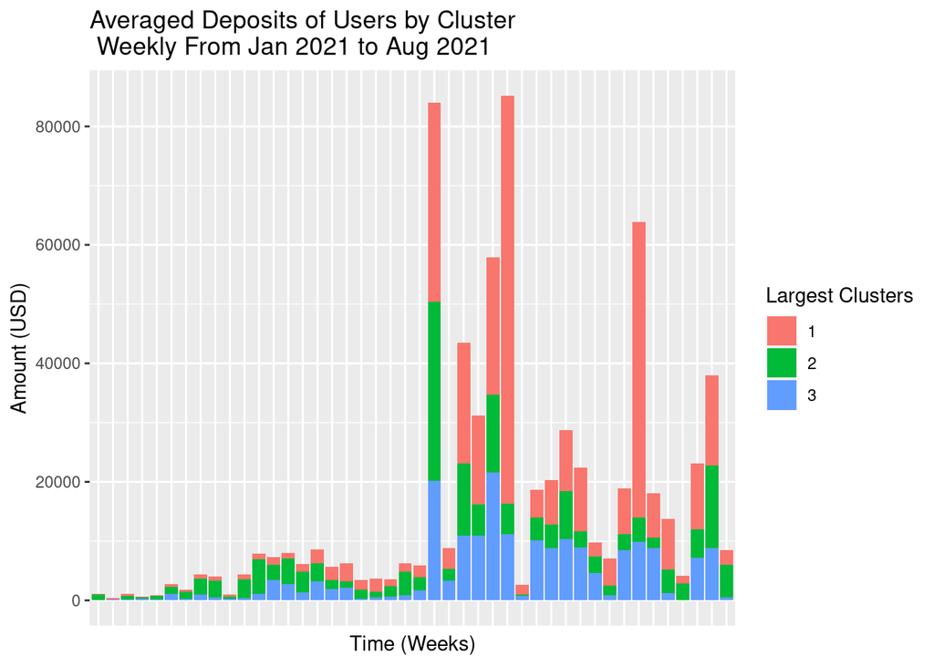

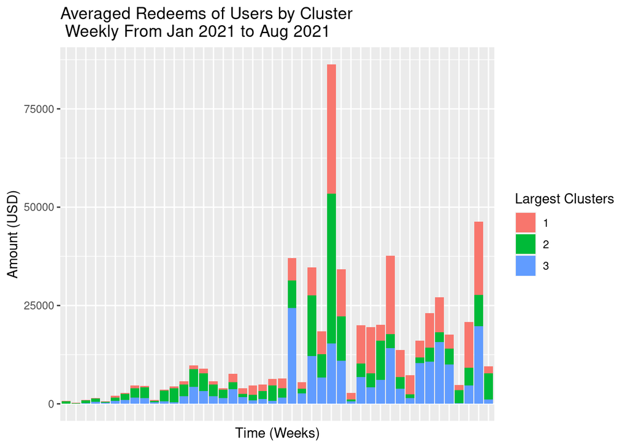

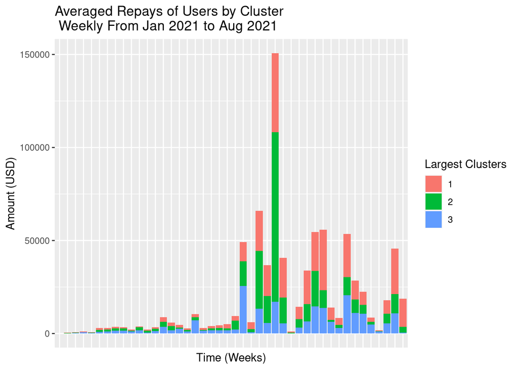

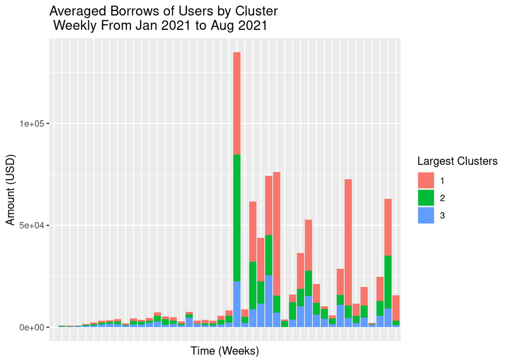

```r
fct_plot_list <- list()
for (m in 1:4) {
  pltobj <- ggplot(count(facet_data_list[[m]] ,ymd_new, cluster, wt =amount, name = "amount")) +
  geom_bar(aes(x=ymd_new,y= amount, fill = as.factor(cluster)),
           stat='identity') + ggtitle(paste0("Averaged ", cap_loop_labels[m], " of Users by Cluster\n Weekly From Jan 2021 to Aug 2021")) + labs(y = "Amount (USD)", x= "Time (Weeks)")+
          theme(
           axis.text.x=element_blank(),
           axis.ticks.x=element_blank()) + labs(fill="Largest Clusters")
  print(pltobj)
  fct.plt <- pltobj +  facet_grid(cols = vars(cluster))
  fct_plot_list[[m]] <-fct.plt
}
```